# PGA Tour Expected Strokes - Approach

Jumping off of [modeling expected strokes for off-the-tee shots](https://basketballrelativity.github.io/personal/driving), the following takes the natural next step to construct an analogous model for approach shots. We'll define approach shots as those following an off-the-tee shot and from a distance of 50 yards or greater.

```python
%pip install pygam

import numpy as np
import pandas as pd

import matplotlib.pyplot as plt
import pickle

from pygam import PoissonGAM, te

from sklearn.model_selection import train_test_split
from sklearn.metrics import mean_absolute_error
from sklearn.preprocessing import KBinsDiscretizer, StandardScaler

import warnings
warnings.filterwarnings('ignore')
```

```python
approach_df = pd.read_csv("/content/drive/MyDrive/Golf/approach.csv")
approach_df
```

|  | event_id | year | player_id | round_num | hole | distance_val | distance | lie | from | to | type | cup | shotNumber | max_strokes | strokes |
| --- | --- | --- | --- | --- | --- | --- | --- | --- | --- | --- | --- | --- | --- | --- | --- |
| 0 | R2022541 | 2022 | 27095 | 2 | 18 | 189.0 | 189 yds | Primary Rough | ORO | ORO | SST | False | 2.0 | 5.0 | 4.0 |
| 1 | R2022540 | 2022 | 49117 | 2 | 1 | 158.0 | 158 yds | Rear Greenside Bunker | OFW | EG8 | SST | False | 2.0 | 5.0 | 4.0 |
| 2 | R202230 | 2022 | 36699 | 4 | 4 | 135.0 | 135 yds | Left Greenside Bunker | OFW | EG6 | SST | False | 2.0 | 4.0 | 3.0 |
| 3 | R2022525 | 2022 | 54628 | 3 | 12 | 285.0 | 285 yds | Front Left Greenside Bunker | OFW | EG5 | SST | False | 2.0 | 5.0 | 4.0 |
| 4 | R202241 | 2022 | 51890 | 2 | 14 | 231.0 | 231 yds | Right Greenside Bunker | OFW | EG2 | SST | False | 2.0 | 5.0 | 4.0 |
| ... | ... | ... | ... | ... | ... | ... | ... | ... | ... | ... | ... | ... | ... | ... | ... |
| 476160 | R202247 | 2022 | 27129 | 2 | 10 | 87.0 | 87 yds | Green | OFW | OGR | SST | False | 2.0 | 3.0 | 2.0 |
| 476161 | R2021527 | 2021 | 22405 | 1 | 10 | 71.0 | 71 yds | Green | OFW | OGR | SST | False | 2.0 | 3.0 | 2.0 |
| 476162 | R202232 | 2022 | 36699 | 2 | 1 | 90.0 | 90 yds | Green | OFW | OGR | SST | False | 2.0 | 3.0 | 2.0 |
| 476163 | R202220 | 2022 | 46340 | 4 | 6 | 127.0 | 127 yds | Green | OFW | OGR | SST | False | 2.0 | 3.0 | 2.0 |
| 476164 | R202254 | 2022 | 29908 | 2 | 17 | 124.0 | 124 yds | Green | OFW | OGR | SST | False | 2.0 | 4.0 | 3.0 |

476165 rows × 15 columns

These data have been filtered and aggregated from the shot-by-shot data. Data cleaning included

- Removing shots with missing or zero distance from the hole
- Ensuring each event-year-golfer-round-hole has a tee shot and hole out
- Removing provisional shots
- Filtering out tee shots and shots within 50 yards from the hole

For modeling expected strokes, the `distance_val` (the distance of the ball from the hole prior to the shot) and `from` (indicator for the lie before the shot) features are of primary interest. `from` is a bit opaque:

```python
list(set(approach_df["from"]))
```

```
['OST',
 'OGS',
 nan,
 'OTO',
 'OTH',
 'OWA',
 'OCO',
 'OFW',
 'OWD',
 'OUK',
 'OIR',
 'ORO',
 'ONA']
```

Leveraging the full shot dataset and cross-referencing the three-letter codes with the `lie` field yields the following:

- `'OTH'`: Other
- `'OWD'`: Water drop area
- `'OST'`: Fairway bunker
- `'OGS'`: Greenside bunker
- `'OFW'`: Fairway
- `'OUK'`: Unknown
- `'ORO'`: Primary rough
- `'OCO'`: Fringe
- `'OWA'`: Water
- `'OIR'`: Intermediate rough
- `'ONA'`: Native area
- `'OTO'`: Tree outline

Filtering out drops (`type == "SDP"`) leaves just bonafide shots in the dataset (`type == "SST"`)

```python
approach_df = approach_df[approach_df["type"]=="SST"]
```

## Visualization

### Strokes Remaining on Approach

Examining strokes remaining provides a sense of the distribution of the target variable for these types of shots.

```python
stroke_counts = list(approach_df.groupby("strokes")["hole"].count() / len(approach_df))
strokes_remaining = np.arange(1, len(stroke_counts) + 1)
```

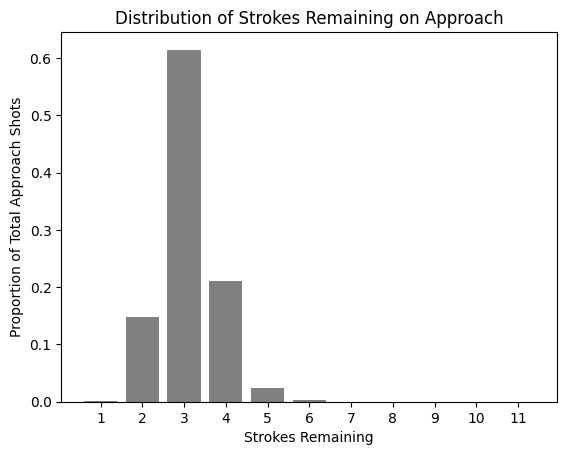

```python
fig, ax = plt.subplots()

# Plot
ax.bar(strokes_remaining, stroke_counts, color="gray")

# Labels
ax.set_xlabel('Strokes Remaining')
ax.set_ylabel('Proportion of Total Approach Shots')
ax.set_title('Distribution of Strokes Remaining on Approach')
ax.set_xticks(strokes_remaining)

plt.show()
```

Over 60% of approach shots have three strokes remaining, with the vast majority of shots remaining falling between one and six.

### Approach Shots by Lie

Similarly, getting a sense of how lies are distributed across approach shots may be helpful.

```python
lie_dict = {
    "OTH": "Other",
    "OWD": "Water drop area",
    "OST": "Fairway bunker",
    "OGS": "Greenside bunker",
    "OFW": "Fairway",
    "OUK": "Unknown",
    "ORO": "Primary rough",
    "OWA": "Water",
    "OIR": "Intermediate rough",
    "ONA": "Native area",
    "OTO": "Tree outline",
    "OCO": "Fringe"
}

# Find number of shots by lie
lie_df = pd.DataFrame(approach_df.groupby("from")["hole"].count()).reset_index()
lie_df.columns = ["lie", "shots"]

# Human-friendly lie types
lie_df = lie_df.sort_values("shots", ascending=True)
lie_df["lie"] = [lie_dict[x] for x in lie_df["lie"]]

# Proportion of shots
denom = np.sum(lie_df["shots"])
lie_df["shots"] /= denom

lie_df
```

|  | lie | shots |
| --- | --- | --- |
| 0 | Fringe | 0.000004 |
| 9 | Unknown | 0.000004 |
| 8 | Tree outline | 0.000013 |
| 10 | Water | 0.000083 |
| 2 | Greenside bunker | 0.000752 |
| 11 | Water drop area | 0.002775 |
| 7 | Other | 0.016576 |
| 4 | Native area | 0.019173 |
| 6 | Fairway bunker | 0.052494 |
| 3 | Intermediate rough | 0.056937 |
| 5 | Primary rough | 0.228946 |
| 1 | Fairway | 0.622243 |

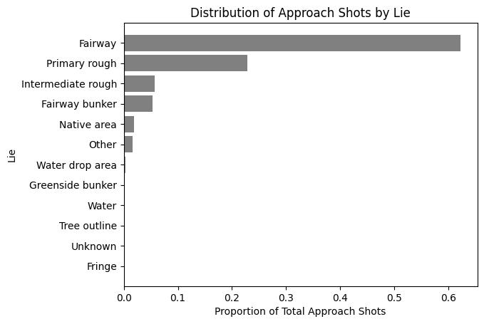

```python
fig, ax = plt.subplots()

# Plot
ax.barh(np.arange(len(lie_df)), lie_df["shots"], color="gray")

# Labels
ax.set_ylabel('Lie')
ax.set_xlabel('Proportion of Total Approach Shots')
ax.set_title('Distribution of Approach Shots by Lie')
ax.set_yticks(np.arange(len(lie_df)))
ax.set_yticklabels(list(lie_df["lie"]))

plt.show()
```

Approach shots are dominated by fairway lies, followed by a list of usual suspects.

### Expected Strokes by Lie and Distance

Since the model will consider lie, examining the effect of both lie and distance together might indicate which modeling choices to make.

```python
# Subset DataFrame to just consider fairway, rough, and bunker shots
type_df = approach_df[approach_df["from"].isin(["OFW", "ORO", "OIR", "OST", "OGS"])].copy()
type_df["lie"] = ["Fairway" if x == "OFW" else
                  "Rough" if x in ["ORO", "OIR"] else
                  "Bunker" for x in type_df["from"]]

# Initialize discretizer
fairway_est = KBinsDiscretizer(n_bins=10, encode='ordinal', strategy='quantile', subsample=None)
rough_est = KBinsDiscretizer(n_bins=10, encode='ordinal', strategy='quantile', subsample=None)
bunker_est = KBinsDiscretizer(n_bins=5, encode='ordinal', strategy='quantile', subsample=None)

# Subset again
fairway_df = type_df[type_df["lie"]=="Fairway"].copy()
rough_df = type_df[type_df["lie"]=="Rough"].copy()
bunker_df = type_df[type_df["lie"]=="Bunker"].copy()

# Fit and transform to bins
fairway_bin = fairway_est.fit_transform(fairway_df[["distance_val"]])
rough_bin = rough_est.fit_transform(rough_df[["distance_val"]])
bunker_bin = bunker_est.fit_transform(bunker_df[["distance_val"]])

# Store
fairway_df["bin"] = [x[0] for x in fairway_bin]
rough_df["bin"] = [x[0] for x in rough_bin]
bunker_df["bin"] = [x[0] for x in bunker_bin]
```

```python
# Mean distance and stroke values by bin
fw_viz = pd.DataFrame(fairway_df.groupby("bin")[["distance_val", "strokes"]].mean()).reset_index()
ro_viz = pd.DataFrame(rough_df.groupby("bin")[["distance_val", "strokes"]].mean()).reset_index()
bu_viz = pd.DataFrame(bunker_df.groupby("bin")[["distance_val", "strokes"]].mean()).reset_index()
```

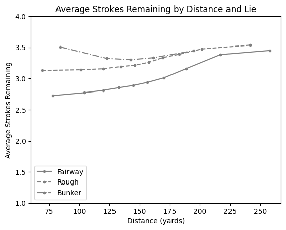

```python
fig, ax = plt.subplots()

# Plot
## Fairway
ax.plot(
        fw_viz["distance_val"], fw_viz["strokes"],
        linestyle='-', marker='o', markersize=3,
        color='gray', label="Fairway"
    )
## Fairway
ax.plot(
        ro_viz["distance_val"], ro_viz["strokes"],
        linestyle='--', marker='o', markersize=3,
        color='gray', label="Rough"
    )
## Bunker
ax.plot(
        bu_viz["distance_val"], bu_viz["strokes"],
        linestyle='-.', marker='o', markersize=3,
        color='gray', label="Bunker"
    )

# Labels
ax.set_xlabel('Distance (yards)')
ax.set_ylabel('Average Strokes Remaining')
ax.set_title('Average Strokes Remaining by Distance and Lie')
ax.legend()
ax.set_ylim(1, 4)

plt.show()
```

# Predictive Model

To capture the nonlinearities present in the above figure, a generalized additive model for Poisson regression seems like a natural choice for our model type. Specifically, with expected strokes $y_i$ for shot $i$:

$$ E[y_i|x_i] = e^{\beta_0 + f(l_i, d_i)} $$

where $l_i$ is a vector of one-hot indicators for the type of lie, and $d_i$ is the distance of the ball from the hole. By modeling $f$ as a tensor spline of the interaction between lie and distance, the model learns a separate nonlinear relationship between distance and expected strokes for each type of lie.

Some light preprocessing follows here:

- The most common lies are maintained, while the others are lumped into an "Other" category
- Factorizing `lie`
- Splitting the dataset
- Standardizing the `distance_val` variable to mean 0 and variance 1

From there, we'll train the model. We'll initialize the tensor spline with 15 splines, but follow up by tuning both the number of splines and the smoothing parameter `lam`.

```python
# Condensing lies
approach_df["lie"] = ["Fairway" if x == "OFW" else
                      "Rough" if x in ["ORO", "OIR"] else
                      "Bunker" if x in ["OST", "OGS"] else
                      "Native Area" if x == "ONA" else
                      "Other" for x in approach_df["from"]]


# Lie index
lies, lie_idx = pd.factorize(approach_df["lie"])
approach_df["lie_idx"] = lies
```

```python
# Input / output
features = ["lie_idx", "distance_norm"]
target = "strokes"

# Split dataset
train_df, test_df = train_test_split(approach_df, test_size=0.2, random_state=42)

# Scale distance
distance_scaler = StandardScaler()
train_df["distance_norm"] = distance_scaler.fit_transform(train_df[["distance_val"]])
test_df["distance_norm"] = distance_scaler.transform(test_df[["distance_val"]])

# Model fitting
gam = PoissonGAM(te(0, 1, n_splines=15), lam=0.6).fit(train_df[features], train_df[target])
gam.summary()
```

```
PoissonGAM
=============================================== ==========================================================
Distribution:                       PoissonDist Effective DoF:                                     27.8937
Link Function:                          LogLink Log Likelihood:                               -592067.6922
Number of Samples:                       377612 AIC:                                          1184191.1718
                                                AICc:                                         1184191.1763
                                                UBRE:                                               2.1293
                                                Scale:                                                 1.0
                                                Pseudo R-Squared:                                   0.1416
==========================================================================================================
Feature Function                  Lambda               Rank         EDoF         P > x        Sig. Code
================================= ==================== ============ ============ ============ ============
te(0, 1)                          [0.6 0.6]            225          27.9         0.00e+00     ***
intercept                                              1            0.0          1.66e-05     ***
==========================================================================================================
Significance codes:  0 '***' 0.001 '**' 0.01 '*' 0.05 '.' 0.1 ' ' 1

WARNING: Fitting splines and a linear function to a feature introduces a model identifiability problem
         which can cause p-values to appear significant when they are not.

WARNING: p-values calculated in this manner behave correctly for un-penalized models or models with
         known smoothing parameters, but when smoothing parameters have been estimated, the p-values
         are typically lower than they should be, meaning that the tests reject the null too readily.
```

```python
# lams = [0.3, 0.6, 0.9]
# n_splines = [10, 15, 20]

# gam.gridsearch(train_df[features], train_df[target], lam=lams, n_splines=n_splines)
```

## Validation

With selected hyperparameters, the following runs through some performance diagnostics for the model.

```python
train_preds = gam.predict(train_df[features])
test_preds = gam.predict(test_df[features])

print("Training Set MAE: " + str(round(mean_absolute_error(train_df["strokes"],
                                                           train_preds), 3)))
print("Test Set MAE: " + str(round(mean_absolute_error(test_df["strokes"],
                                                       test_preds), 3)))
```

```
Training Set MAE: 0.486
Test Set MAE: 0.482
```

Comparable test and training set performance should assuage any overfitting concerns, but visualizing the expected strokes and actual strokes alongside one another will illustrate whether the GAM captures model behavior well.

To produce the expected strokes as a function of the covariates, the following produces a synthetic dataset and converts it to the format expected by the model for prediction.

```python
# Range between two standard deviations of shot distance
distance_norm = np.linspace(-2, 2, num=100)
distance_vals = distance_scaler.inverse_transform(distance_norm.reshape(-1, 1))
distance_vals = distance_vals.reshape(1, -1)[0]
# Loop through each type of lie and generate predictions
all_df = pd.DataFrame()
for val in range(len(lie_idx)):
    temp_df = pd.DataFrame(
        {
            "distance_norm": distance_norm,
            "distance_vals": distance_vals,
            "lie_idx": val,
            "lie": lie_idx[val]
        }
    )
    preds = gam.predict(temp_df[features])
    temp_df["preds"] = preds
    all_df = pd.concat([all_df, temp_df])
all_df
```

|  | distance_norm | distance_vals | lie_idx | lie | preds |
| --- | --- | --- | --- | --- | --- |
| 0 | -2.000000 | 53.454328 | 0 | Rough | 3.106412 |
| 1 | -1.959596 | 55.492777 | 0 | Rough | 3.106412 |
| 2 | -1.919192 | 57.531226 | 0 | Rough | 3.106511 |
| 3 | -1.878788 | 59.569675 | 0 | Rough | 3.106710 |
| 4 | -1.838384 | 61.608124 | 0 | Rough | 3.107011 |
| ... | ... | ... | ... | ... | ... |
| 95 | 1.838384 | 247.106996 | 4 | Bunker | 3.687768 |
| 96 | 1.878788 | 249.145445 | 4 | Bunker | 3.694513 |
| 97 | 1.919192 | 251.183894 | 4 | Bunker | 3.700713 |
| 98 | 1.959596 | 253.222343 | 4 | Bunker | 3.706335 |
| 99 | 2.000000 | 255.260792 | 4 | Bunker | 3.711347 |

500 rows × 5 columns

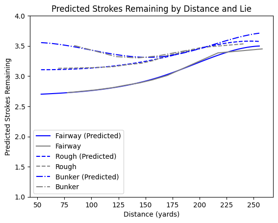

```python
fig, ax = plt.subplots()

# Plot
## Fairway
ax.plot(
        all_df[all_df["lie"]=="Fairway"]["distance_vals"],
        all_df[all_df["lie"]=="Fairway"]["preds"],
        linestyle='-', markersize=1,
        color='blue', label="Fairway (Predicted)"
    )
ax.plot(
        fw_viz["distance_val"], fw_viz["strokes"],
        linestyle='-', markersize=3,
        color='gray', label="Fairway"
    )
## Rough
ax.plot(
        all_df[all_df["lie"]=="Rough"]["distance_vals"],
        all_df[all_df["lie"]=="Rough"]["preds"],
        linestyle='--', markersize=1,
        color='blue', label="Rough (Predicted)"
    )
ax.plot(
        ro_viz["distance_val"], ro_viz["strokes"],
        linestyle='--', markersize=3,
        color='gray', label="Rough"
    )
## Bunker
ax.plot(
        all_df[all_df["lie"]=="Bunker"]["distance_vals"],
        all_df[all_df["lie"]=="Bunker"]["preds"],
        linestyle='-.', markersize=1,
        color='blue', label="Bunker (Predicted)"
    )
ax.plot(
        bu_viz["distance_val"], bu_viz["strokes"],
        linestyle='-.', markersize=3,
        color='gray', label="Bunker"
    )

# Labels
ax.set_xlabel('Distance (yards)')
ax.set_ylabel('Predicted Strokes Remaining')
ax.set_title('Predicted Strokes Remaining by Distance and Lie')
ax.legend()
ax.set_ylim(1, 4)

plt.show()
```

The model captures the nonlinear relationship between distance and expected strokes for each type of lie quite well. By binning distance and strokes for the empirical values, assessing the fit of the model at the tails of distance for each lie is difficult. So, for one last validation step, let's take a look at overall calibration.

```python
# Initialize discretizer
test_df["preds"] = test_preds
overall_est = KBinsDiscretizer(n_bins=10, encode='ordinal', strategy='quantile', subsample=None)

# Fit and transform to bins
strokes_bin = overall_est.fit_transform(test_df[["preds"]])

# Store
test_df["bin"] = [x[0] for x in strokes_bin]
overall_viz = pd.DataFrame(test_df.groupby("bin")[["strokes", "preds"]].mean()).reset_index()
```

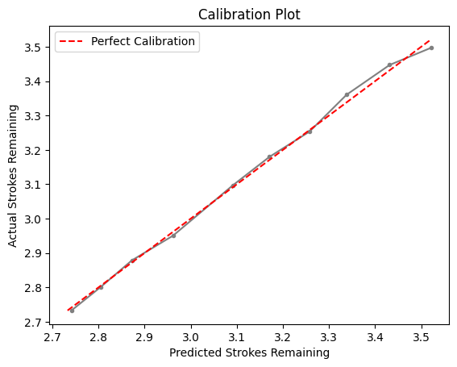

```python
fig, ax = plt.subplots()

# Plot
ax.plot(overall_viz["preds"], overall_viz["strokes"], linestyle='-', marker='o', markersize=3, color='gray')

# Add a diagonal line for perfect calibration
min_val = min(overall_viz["preds"].min(), overall_viz["strokes"].min())
max_val = max(overall_viz["preds"].max(), overall_viz["strokes"].max())
ax.plot([min_val, max_val], [min_val, max_val], linestyle='--', color='red', label="Perfect Calibration")

# Labels
ax.set_xlabel('Predicted Strokes Remaining')
ax.set_ylabel('Actual Strokes Remaining')
ax.set_title('Calibration Plot')
ax.legend()

plt.show()
```

The model seems generally well-calibrated, even at the extremes, although there are slight signs of under- and over-prediction at the high end of predicted strokes remaining.

# Conclusion

The GAM developed here captures the behavior of expected strokes as a function of shot distance and lie, demonstrating well-calibrated predictions. To wrap up, the following stores the scaler and model for future use.

```python
objs = {
    "distance_scaler": distance_scaler,
    "model": gam
}

with open('/content/drive/MyDrive/Golf/approach_objs.pkl', 'wb') as handle:
    pickle.dump(objs, handle)
```